# Evidence1_Introduction_to_econometrics

Mariana Manzano Rico

2023-08-14

# MEXICO AND ITS ATTRACTIVENESS FOR NEARSHORING

In the last years and after the pandemic, the suspension of activities in one of the most productive countries had several consequences which affected not only multiple productive processes for China but for its main trading partners. (Shih, 2020).

But not only the pandemic had different effects on the world, also the trade war between China and the United States caused that many american companies decided to close their factories and working centers in the Asian country, as well as in Russia and Ukraine after the conflict between those two countries (BBVA, 2022).

That is why many countries are looking for new places where to start their businesses (especially manufacturing), a phenomena called nearshoring, which means move factories to cheaper places, considering salaries, fuel, supplies, electricity and taxes.

Many people think Mexico is the perfect place thanks to its proximity with United States and low-cost workforce. So…

### Why Mexico is so special for nearshoring?

The following are some reasons why our country might be the best option for foreign investment:

- First, its 3,152 kilometers of frontier with the American Country
- The different free trade agreements with USA and Canada, which can reduce taxes.
- 80% of the industrial productoin in Mexico goes to United States.
- Its easier to coordinate operations with american partners thanks to the similar time zone.
- According to the Banco Interamericano de Desarrollo (BID), 78 billion USD each year will be exported from Latin America. 45% of the total will come from Mexico.

(Lázaro, 2022)

### How is it going?

In the opinion of an analyst from the Barclays Global Bank, nearshoring in Mexico is already felt with the record of foreign direct investment. (Lázaro, 2022). In addition, other sources suggest that the relocation of businesses in our country has been representing an economic growth of 1.4% each year since 2018. After that, no growth was registered.

However, it is important to understand the different factors that external countries consider when deciding to invest in Mexican territory, so strategies can be created and applied in order to promote nearshoring, the generation of new businesses and the increase of Mexican economy in the following years.

With that in mind, an analysis with Regression Models will be developed to comprehend the impact of different variables in foreign investments, using a database with information registered by different institutions such as the National Institute of Statistics and Geography (INEGI), the Bank of Mexico (Banxico) and the Ministry of Economy (SE, 2023).

## Our Database “Nearshoring”

Our database is the following one:

```
##       Año         IED_Flujos    Exportaciones      Empleo
##  Min.   :1997   Min.   : 8374   Min.   : 9088   Length:26
##  1st Qu.:2003   1st Qu.:21367   1st Qu.:13260   Class :character
##  Median :2010   Median :27698   Median :21188   Mode  :character
##  Mean   :2010   Mean   :26770   Mean   :23601
##  3rd Qu.:2016   3rd Qu.:32183   3rd Qu.:31601
##  Max.   :2022   Max.   :48354   Max.   :46478
##   Educación         Salario_Diario   Innovación        Inseguridad_Robo
##  Length:26          Min.   : 24.3   Length:26          Min.   :120
##  Class :character   1st Qu.: 42.0   Class :character   1st Qu.:148
##  Mode  :character   Median : 54.5   Mode  :character   Median :182
##                     Mean   : 65.2                      Mean   :185
##                     3rd Qu.: 72.3                      3rd Qu.:210
##                     Max.   :172.9                      Max.   :315
##  Inseguridad_Homicidio Tipo_de_Cambio  Densidad_Carretera Densidad_Población
##  Length:26             Min.   : 8.06   Min.   :0.0521     Min.   :47.4
##  Class :character      1st Qu.:10.75   1st Qu.:0.0595     1st Qu.:52.8
##  Mode  :character      Median :13.02   Median :0.0699     Median :58.1
##                        Mean   :13.91   Mean   :0.0711     Mean   :57.3
##                        3rd Qu.:18.49   3rd Qu.:0.0827     3rd Qu.:61.4
##                        Max.   :20.66   Max.   :0.0902     Max.   :65.6
##  CO2_Emisiones      PIB_Per_Cápita        INPC
##  Length:26          Min.   :126739   Min.   : 33.3
##  Class :character   1st Qu.:130964   1st Qu.: 56.1
##  Mode  :character   Median :136846   Median : 73.3
##                     Mean   :138550   Mean   : 75.2
##                     3rd Qu.:146148   3rd Qu.: 91.3
##                     Max.   :153236   Max.   :126.5
```

Where y will be the variable named as IED_Flujos since it refers to the foreign investment made through the years. We also have other variables like Education, Insecurity, Innovation, Exchange Rate, among others.

To understand the relationships between variables, we did the following graph.

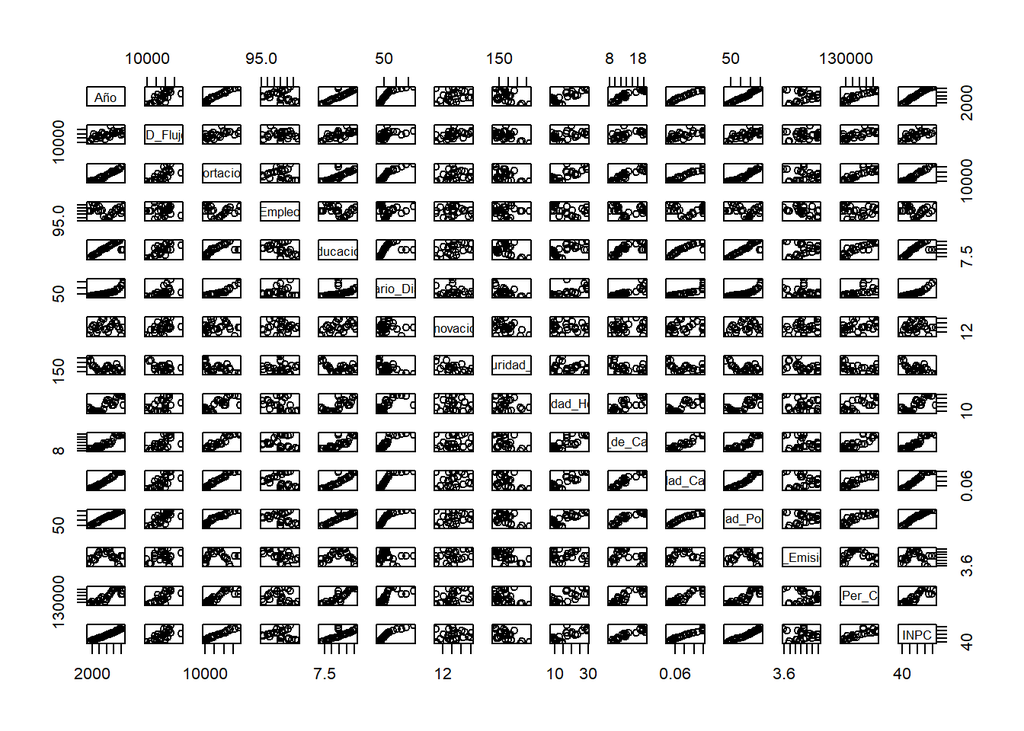

We notice that there are many variables that seems to don’t have any relation, while others do. However, at this moment is only important to understand the association with IED_Flujos, so we decided to calculate the correlation between each variable with Y.

Not all connections were strong, but the ones that had the highest correlation were:

```
## [1] 0.723
```

```
## [1] 0.724
```

```
## [1] 0.719
```

```
## [1] 0.734
```

```
## [1] 0.705
```

This factors mean:

- Year: Time.
- Education: Average Years of Education.
- Population Density: The number of population divided by the territorial extension of Mexico in km2.
- GDP: Gross Domestic Product (GDP) divided by population. Value adjusted by 2013 prices.
- INPC: National Consumer Price Index (NCPI). Base 2018 = 100.

With this components we will construct our models and then decide which one is the best one:

## Creation of the models

### Simple Linear Regression

**1st Model, Year and Investment**

Our first model was created to observe how external investment has been developing through time.

```
## [1] 0.723
```

```
##
## Call:
## lm(formula = near1$IED_Flujos ~ near2$Año)
##
## Residuals:
##    Min     1Q Median     3Q    Max
##  -8860  -3859   -397   2794  18682
##
## Coefficients:
##             Estimate Std. Error t value Pr(>|t|)
## (Intercept) -1639682     324864   -5.05 0.000037 ***
## near2$Año        829        162    5.13 0.000030 ***
## ---
## Signif. codes:  0 '***' 0.001 '**' 0.01 '*' 0.05 '.' 0.1 ' ' 1
##
## Residual standard error: 6180 on 24 degrees of freedom
## Multiple R-squared:  0.523,  Adjusted R-squared:  0.503
## F-statistic: 26.3 on 1 and 24 DF,  p-value: 0.0000299
```

First, we see a high correlation compared to others in our first tries. Then we see that both (the intercept and the variable) are significant for our models, and the model as well is significant. However, we notice a low Adjusted R-squared, this value tells us that only 50% of the investment is explained by the years.

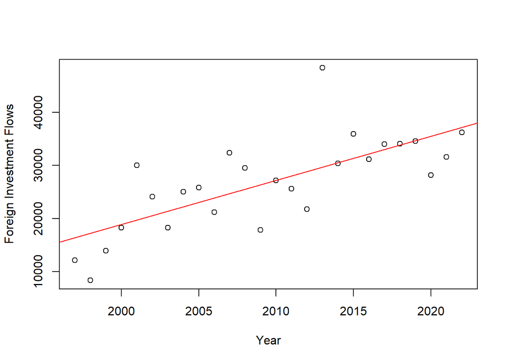

```
## integer(0)
```

Our graph illustrates that there is a trend in this variable, however, is not precise enough for our model.

```
##
##  Shapiro-Wilk normality test
##
## data:  rstandard(ModSimple1)
## W = 0.9, p-value = 0.07
```

```
## [1] 532
```

```
## [1] 535
```

**2nd Model, GDP and Investment**

Our second model evaluates de relationship between GDP and investment flows. FIrst we have the following correlation:

```
## [1] 0.734
```

Which means that it is strong but it can be better. On the other hand, our model is:

```
##
## Call:
## lm(formula = near1$IED_Flujos ~ near2$PIB_Per_Cápita)
##
## Residuals:
##    Min     1Q Median     3Q    Max
##  -9813  -3558  -1388   3078  17542
##
## Coefficients:
##                        Estimate Std. Error t value Pr(>|t|)
## (Intercept)          -73918.429  19042.202   -3.88  0.00071 ***
## near2$PIB_Per_Cápita      0.727      0.137    5.30  0.00002 ***
## ---
## Signif. codes:  0 '***' 0.001 '**' 0.01 '*' 0.05 '.' 0.1 ' ' 1
##
## Residual standard error: 6080 on 24 degrees of freedom
## Multiple R-squared:  0.539,  Adjusted R-squared:  0.52
## F-statistic: 28.1 on 1 and 24 DF,  p-value: 0.0000196
```

As we can see, both variables are significant, our model is significant as well, but only 51% of our model explains the behavior of y, which is not a great percentage.

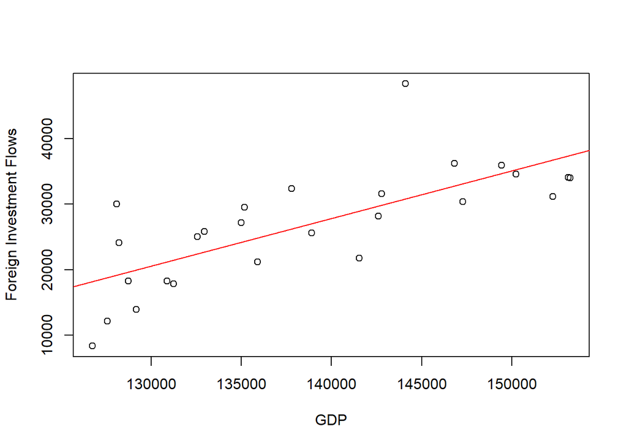

```
## integer(0)
```

In our graph, we see again that there is a trend between variables, but not as precise as we wanted.

Additionally, our evaluation methods indicates the following values:

```
##
##  Shapiro-Wilk normality test
##
## data:  rstandard(ModSimple2)
## W = 0.9, p-value = 0.1
```

```
## [1] 531
```

```
## [1] 535
```

**3rd Model, Education and Investment**

Other model we tried was with Education and Investment, since it throws us a correlation of:

```
## [1] 0.724
```

That is why, we decided to build the following model:

```
##
## Call:
## lm(formula = near1$IED_Flujos ~ near2$Educación)
##
## Residuals:
##    Min     1Q Median     3Q    Max
## -10352  -3378  -1257   2290  16494
##
## Coefficients:
##                 Estimate Std. Error t value Pr(>|t|)
## (Intercept)       -50457      15060   -3.35   0.0027 **
## near2$Educación     9146       1778    5.14 0.000029 ***
## ---
## Signif. codes:  0 '***' 0.001 '**' 0.01 '*' 0.05 '.' 0.1 ' ' 1
##
## Residual standard error: 6170 on 24 degrees of freedom
## Multiple R-squared:  0.524,  Adjusted R-squared:  0.505
## F-statistic: 26.5 on 1 and 24 DF,  p-value: 0.0000288
```

We see in this part that the Intercept (the value that y might have if x is 0), is not as significant as the variable education, but it is the enough for our model. Also we see a significant p-value but again, according to our Adjusted R-squared, only 50% of the y values can be explained with this model, that means that only 50% of the investment flows in Mexico are thanks to the levels of education.

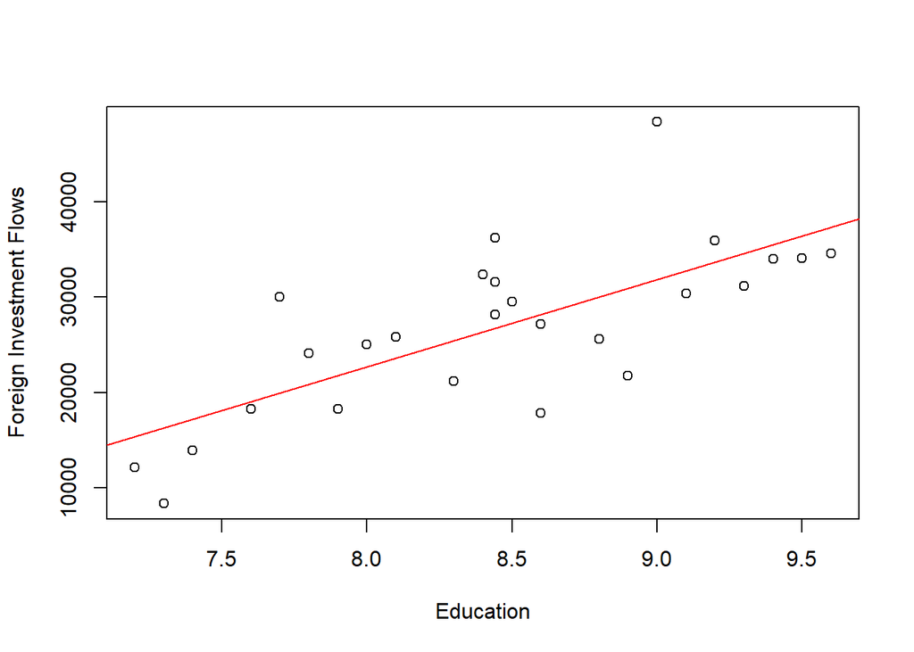

```
## integer(0)
```

The graph shows this trend but as our Adjusted R-squared explains, is not accurate enough.

```
##
##  Shapiro-Wilk normality test
##
## data:  rstandard(ModSimple3)
## W = 0.9, p-value = 0.2
```

```
## [1] 532
```

```
## [1] 535
```

Finally, the Shapiro’s Test indicates it is a functional model but our AIC and BIC are not better compared to the other ones.

**4th Model, Population Density and Investment**

The following method using Population Density and Investment Flows presents a correlation of:

```
## [1] 0.719
```

With this in mind, our model seems like:

```
##
## Call:
## lm(formula = near1$IED_Flujos ~ near2$Densidad_Población)
##
## Residuals:
##    Min     1Q Median     3Q    Max
##  -9384  -3313   -357   2735  19069
##
## Coefficients:
##                          Estimate Std. Error t value Pr(>|t|)
## (Intercept)                -40057      13236   -3.03   0.0058 **
## near2$Densidad_Población     1166        230    5.07 0.000035 ***
## ---
## Signif. codes:  0 '***' 0.001 '**' 0.01 '*' 0.05 '.' 0.1 ' ' 1
##
## Residual standard error: 6220 on 24 degrees of freedom
## Multiple R-squared:  0.517,  Adjusted R-squared:  0.497
## F-statistic: 25.7 on 1 and 24 DF,  p-value: 0.0000348
```

With both (the intercept and the variable) significant and a p-value also significant, our model is not one of the best ones thanks to its low Adjusted R-squared of 49%.

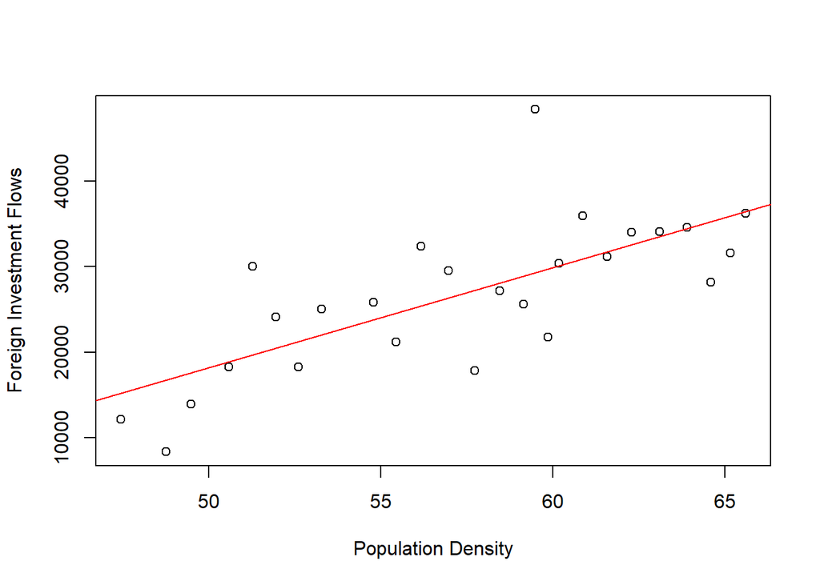

```
## integer(0)
```

This also can be noticed in the image where again, is not exact enough.

```
##
##  Shapiro-Wilk normality test
##
## data:  rstandard(ModSimple4)
## W = 0.9, p-value = 0.06
```

```
## [1] 532
```

```
## [1] 536
```

Our criteria tells us that this model has distributed data which is good, while our BIC and AIC are almost the same than the others.

**5th Model, INPC and Investment**

Our final model was with INPC with a correlation of:

```
## [1] 0.705
```

Then, our model indicates that the intercept is not significant but the p-value is and the behavior of y is 47% explained by the behavior of x.

```
##
## Call:
## lm(formula = near1$IED_Flujos ~ near2$INPC)
##
## Residuals:
##    Min     1Q Median     3Q    Max
##  -9502  -4041    180   2669  19442
##
## Coefficients:
##             Estimate Std. Error t value Pr(>|t|)
## (Intercept)   8041.4     4045.2    1.99    0.058 .
## near2$INPC     249.1       51.2    4.87 0.000058 ***
## ---
## Signif. codes:  0 '***' 0.001 '**' 0.01 '*' 0.05 '.' 0.1 ' ' 1
##
## Residual standard error: 6350 on 24 degrees of freedom
## Multiple R-squared:  0.497,  Adjusted R-squared:  0.476
## F-statistic: 23.7 on 1 and 24 DF,  p-value: 0.0000583
```

In our graph we see almost the same situation, a trend but not the accuracy of the data.

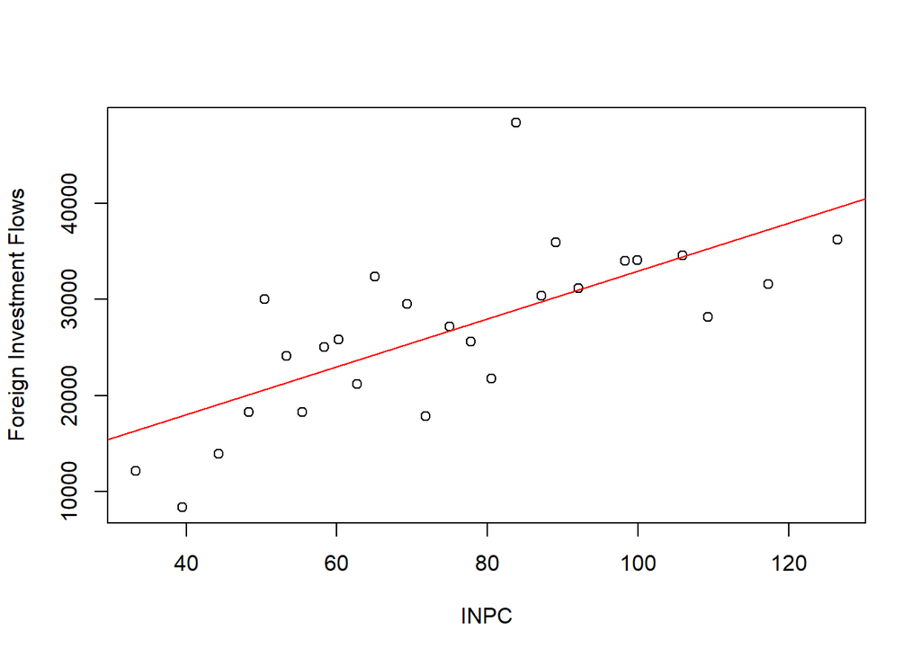

```
## integer(0)
```

```
##
##  Shapiro-Wilk normality test
##
## data:  rstandard(ModSimple5)
## W = 0.9, p-value = 0.09
```

```
## [1] 533
```

```
## [1] 537
```

Finally, the p-value in the Shapiro test is non-significant (our data is well distributed), but AIC and BIC are higher than the other models.

### Multiple Linear Regression

Then we looked for Multiple Linear Regression that may help us to explain which are the factors that other countries take into consideration when they look for the best option to finance. Our models are the following ones:

**1st Model, all variables**

Our first model takes all the available variables to construct our model. This one has the following statistics:

```
##
## Call:
## lm(formula = near2$IED_Flujos ~ near2$Año + near2$Exportaciones +
##     near2$Empleo + near2$Educación + near2$Salario_Diario +
##     near2$Innovación + near2$Inseguridad_Robo + near2$Inseguridad_Homicidio +
##     near2$Tipo_de_Cambio + near2$Densidad_Carretera + near2$Densidad_Población +
##     near2$CO2_Emisiones + near2$PIB_Per_Cápita + near2$INPC)
##
## Residuals:
##    Min     1Q Median     3Q    Max
##  -7097  -1061   -222   1680   4874
##
## Coefficients:
##                                  Estimate    Std. Error t value Pr(>|t|)
## (Intercept)                 -33810874.528   9145063.251   -3.70   0.0035 **
## near2$Año                       16973.249      4579.182    3.71   0.0035 **
## near2$Exportaciones                -3.286         1.102   -2.98   0.0125 *
## near2$Empleo                     5872.763      2495.118    2.35   0.0382 *
## near2$Educación                -18781.399     13005.656   -1.44   0.1766
## near2$Salario_Diario             -287.811       252.450   -1.14   0.2785
## near2$Innovación                 3816.910      1576.380    2.42   0.0339 *
## near2$Inseguridad_Robo             41.595        55.391    0.75   0.4685
## near2$Inseguridad_Homicidio       764.714       555.120    1.38   0.1957
## near2$Tipo_de_Cambio            -3920.133      1047.525   -3.74   0.0033 **
## near2$Densidad_Carretera      -778218.591   1168172.202   -0.67   0.5190
## near2$Densidad_Población       -11300.590      5162.372   -2.19   0.0511 .
## near2$CO2_Emisiones              5040.550     14819.888    0.34   0.7402
## near2$PIB_Per_Cápita                0.314         0.743    0.42   0.6811
## near2$INPC                        554.258       974.760    0.57   0.5810
## ---
## Signif. codes:  0 '***' 0.001 '**' 0.01 '*' 0.05 '.' 0.1 ' ' 1
##
## Residual standard error: 4020 on 11 degrees of freedom
## Multiple R-squared:  0.908,  Adjusted R-squared:  0.79
## F-statistic: 7.71 on 14 and 11 DF,  p-value: 0.000833
```

Here we see that our model is significant and explains the 78% of the data points in y (of the investment). However, only a few factors are significant in our model:

- Year
- Exports
- Employment
- Innovation
- Exchange rate

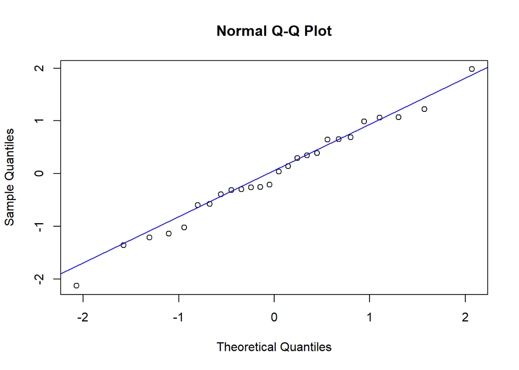

In our graph we see that data is more precise but not in its totality.

```
##
##  Shapiro-Wilk normality test
##
## data:  rstandard(ModMulti1)
## W = 1, p-value = 1
```

```
## [1] 515
```

```
## [1] 535
```

**2nd Model, significant variables in our last model**

As we mentioned, only a few factors were significant in our first model, so we decided to choose those to create a new model. To remember which ones where selected, here they are:

- Year
- Exports
- Employment
- Innovation
- Exchange rate

```
##
## Call:
## lm(formula = near2$IED_Flujos ~ near2$Año + near2$Exportaciones +
##     near2$Empleo + near2$Innovación + near2$Tipo_de_Cambio)
##
## Residuals:
##    Min     1Q Median     3Q    Max
##  -8341  -1849    239   1040  15592
##
## Coefficients:
##                          Estimate   Std. Error t value Pr(>|t|)
## (Intercept)          -5532923.415  1989852.953   -2.78    0.012 *
## near2$Año                2625.794      952.001    2.76    0.012 *
## near2$Exportaciones        -0.651        0.540   -1.21    0.242
## near2$Empleo             3057.419     1727.838    1.77    0.092 .
## near2$Innovación         2079.791     1142.747    1.82    0.084 .
## near2$Tipo_de_Cambio    -1701.761      764.774   -2.23    0.038 *
## ---
## Signif. codes:  0 '***' 0.001 '**' 0.01 '*' 0.05 '.' 0.1 ' ' 1
##
## Residual standard error: 5020 on 20 degrees of freedom
## Multiple R-squared:  0.738,  Adjusted R-squared:  0.673
## F-statistic: 11.3 on 5 and 20 DF,  p-value: 0.0000283
```

In this case, we see that only Year and Exchange Rate are significant, so this ones will be used in our next model. In this one, we also see that the model is significant and that it explains 67% of the behavior of investment flows in Mexico.

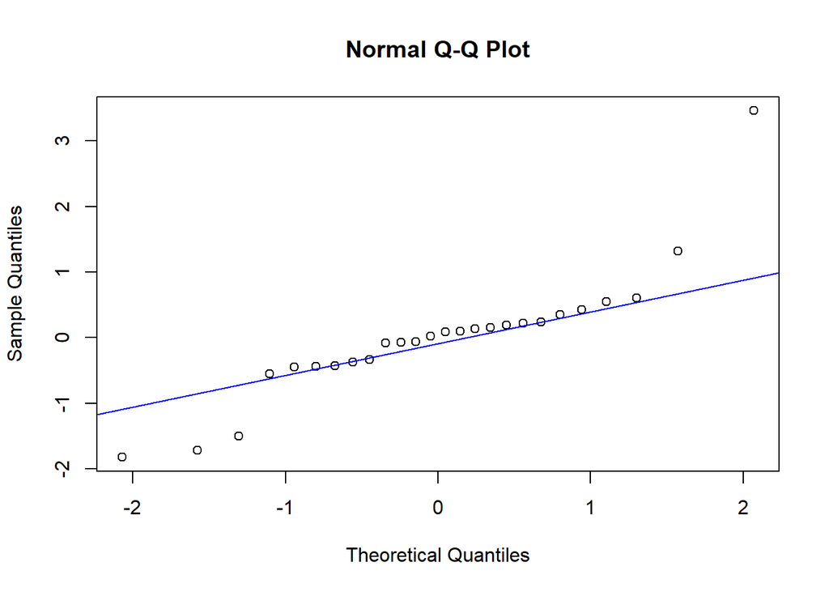

This also can be seen in our chart, which there are many data points really far from the tendency (at least more than in the last model).

```
##
##  Shapiro-Wilk normality test
##
## data:  rstandard(ModMulti2)
## W = 0.8, p-value = 0.0007
```

```
## [1] 524
```

```
## [1] 533
```

**3rd Model, Year and Exchange Rate**

As we said before, we used our significant variables in our last model to create a new one which were Year and Exchange Rate.

```
##
## Call:
## lm(formula = near2$IED_Flujos ~ near2$Año + near2$Tipo_de_Cambio)
##
## Residuals:
##    Min     1Q Median     3Q    Max
## -10197  -3470  -1045   3899  14947
##
## Coefficients:
##                      Estimate Std. Error t value Pr(>|t|)
## (Intercept)          -3078691     913710   -3.37   0.0026 **
## near2$Año                1555        460    3.38   0.0026 **
## near2$Tipo_de_Cambio    -1422        848   -1.68   0.1072
## ---
## Signif. codes:  0 '***' 0.001 '**' 0.01 '*' 0.05 '.' 0.1 ' ' 1
##
## Residual standard error: 5960 on 23 degrees of freedom
## Multiple R-squared:  0.575,  Adjusted R-squared:  0.538
## F-statistic: 15.6 on 2 and 23 DF,  p-value: 0.0000534
```

However, we can see that this is not a good model compared with the other ones thus it has a lower Adjusted R-squared, only 53% of our data is explained with our model, but other models explains at most 78% of our data.

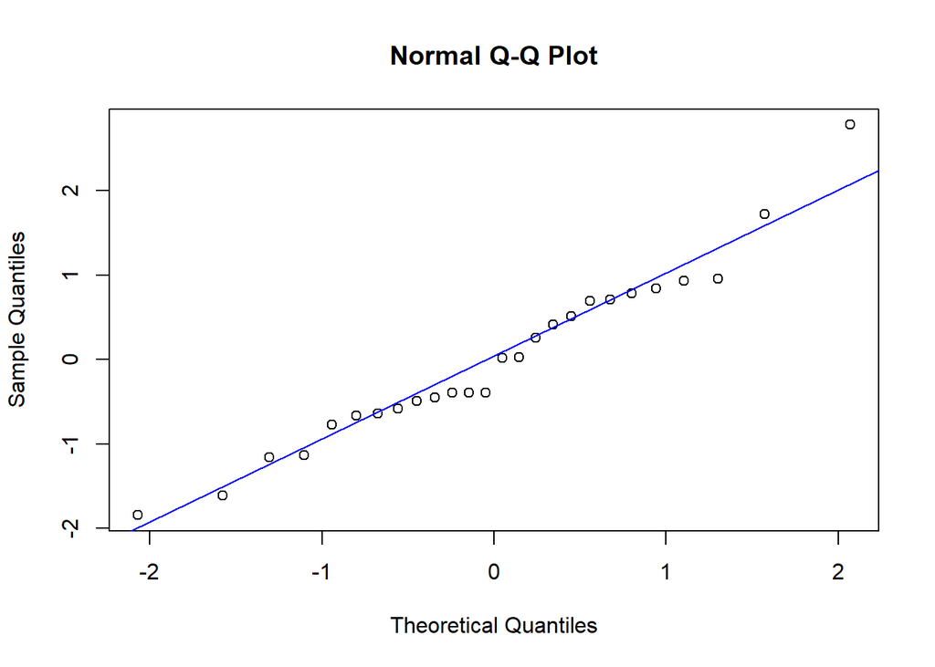

The graph illustrates how this behavior is seen, we can see that are some outliers that do not fit in the model.

Finally, the Shapiro Test tells us that data normally dispersed but, again, AIC and BIC does not present the best values.

```
##
##  Shapiro-Wilk normality test
##
## data:  rstandard(ModMulti3)
## W = 1, p-value = 0.5
```

```
## [1] 531
```

```
## [1] 536
```

**4th Model, going back to a few models**

Because our 3rd model did not present good results, we decided to go back to the first one and only select those variables that where significant and other ones with a low p-value. The list of the variables is the following one:

- Year
- Exports
- Employment
- Education
- Daily Wage
- Innovation
- Insecurity on robberies
- Homicide insecurity
- Exchange rate
- Population density

Our model is:

```
##
## Call:
## lm(formula = near2$IED_Flujos ~ near2$Año + near2$Exportaciones +
##     near2$Empleo + near2$Educación + near2$Salario_Diario +
##     near2$Innovación + near2$Inseguridad_Robo + near2$Inseguridad_Homicidio +
##     near2$Tipo_de_Cambio + near2$Densidad_Población)
##
## Residuals:
##    Min     1Q Median     3Q    Max
##  -6479  -1989    775   1631   6148
##
## Coefficients:
##                                  Estimate    Std. Error t value Pr(>|t|)
## (Intercept)                 -33271184.499   6428797.301   -5.18  0.00011 ***
## near2$Año                       16697.829      3243.229    5.15  0.00012 ***
## near2$Exportaciones                -3.152         0.801   -3.93  0.00133 **
## near2$Empleo                     5618.390      1952.531    2.88  0.01151 *
## near2$Educación                -18608.012      7710.647   -2.41  0.02906 *
## near2$Salario_Diario             -222.919       158.726   -1.40  0.18056
## near2$Innovación                 3976.421      1285.543    3.09  0.00742 **
## near2$Inseguridad_Robo             55.002        43.994    1.25  0.23037
## near2$Inseguridad_Homicidio       378.531       397.476    0.95  0.35602
## near2$Tipo_de_Cambio            -4265.038       821.659   -5.19  0.00011 ***
## near2$Densidad_Población        -9799.924      2575.639   -3.80  0.00173 **
## ---
## Signif. codes:  0 '***' 0.001 '**' 0.01 '*' 0.05 '.' 0.1 ' ' 1
##
## Residual standard error: 3680 on 15 degrees of freedom
## Multiple R-squared:  0.894,  Adjusted R-squared:  0.824
## F-statistic: 12.7 on 10 and 15 DF,  p-value: 0.0000132
```

We see that in this case, Daily wage, Insecurity in robberies and Homicide insecurity are not significant, but our model is and it has the highest percentage of explanation of y (82%).

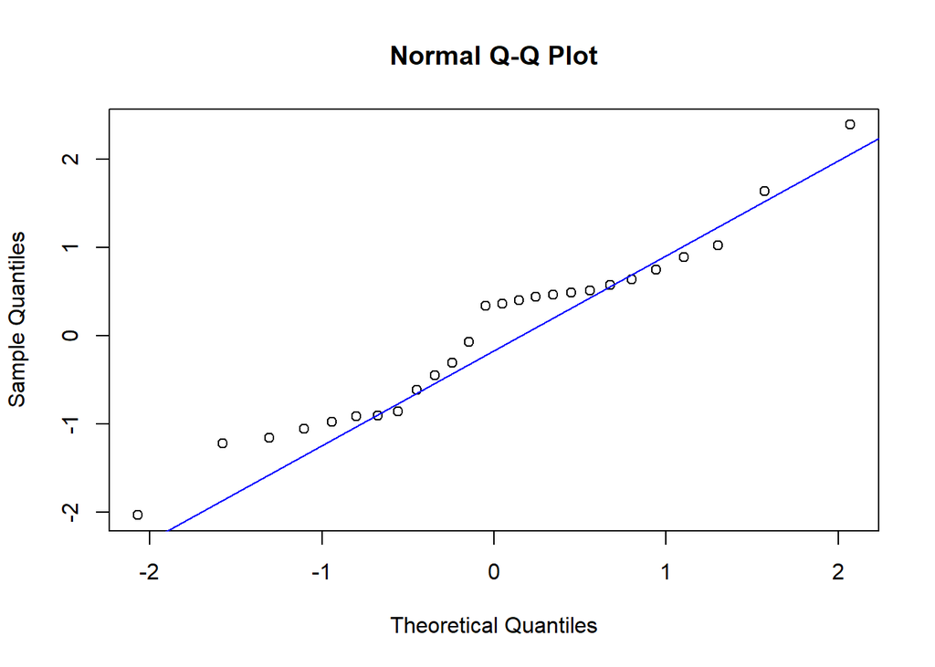

We see again that there are some outliers, but there is a trend in our data points.

```
##
##  Shapiro-Wilk normality test
##
## data:  rstandard(ModMulti4)
## W = 1, p-value = 0.4
```

```
## [1] 510
```

```
## [1] 526
```

The Shapiro Test speculates that data is well disperse, while AIC and BIC have good values in comparison with other models.

Because in our last model we have some insignificant factors, we decided to take them away (except for Daily wage because it hast the lowest p-value of those three) and keep only those which were significant:

- Year
- Exports
- Employment
- Education
- Daily wage
- Innovation
- Exchange rate
- Population density

```
##
## Call:
## lm(formula = near2$IED_Flujos ~ near2$Año + near2$Exportaciones +
##     near2$Empleo + near2$Educación + near2$Salario_Diario +
##     near2$Innovación + near2$Tipo_de_Cambio + near2$Densidad_Población)
##
## Residuals:
##    Min     1Q Median     3Q    Max
##  -5702  -2182    309   1796   8123
##
## Coefficients:
##                               Estimate    Std. Error t value Pr(>|t|)
## (Intercept)              -25055259.671   6124296.152   -4.09  0.00076 ***
## near2$Año                    12656.140      3121.176    4.05  0.00082 ***
## near2$Exportaciones             -1.965         0.717   -2.74  0.01400 *
## near2$Empleo                  3080.346      1724.120    1.79  0.09184 .
## near2$Educación              -7423.193      6358.403   -1.17  0.25914
## near2$Salario_Diario          -126.519       148.824   -0.85  0.40707
## near2$Innovación              2324.721       963.457    2.41  0.02740 *
## near2$Tipo_de_Cambio         -3028.813       727.894   -4.16  0.00065 ***
## near2$Densidad_Población     -9047.235      2591.024   -3.49  0.00279 **
## ---
## Signif. codes:  0 '***' 0.001 '**' 0.01 '*' 0.05 '.' 0.1 ' ' 1
##
## Residual standard error: 4110 on 17 degrees of freedom
## Multiple R-squared:  0.851,  Adjusted R-squared:  0.781
## F-statistic: 12.1 on 8 and 17 DF,  p-value: 0.0000118
```

With these variables, we have that 78% of data can be explained by the model, and that Employment, Education and Daily wage are not significant.

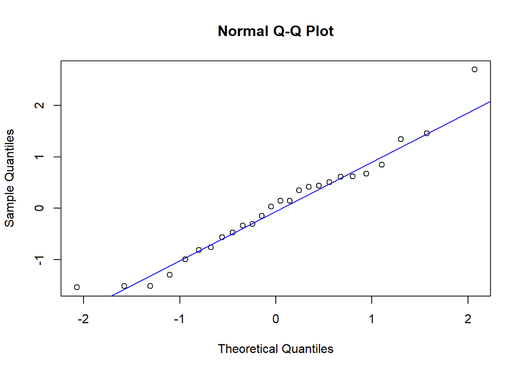

On the image we can see how this data is visualized and that there are some outliers.

```
##
##  Shapiro-Wilk normality test
##
## data:  rstandard(ModMulti5)
## W = 1, p-value = 0.4
```

```
## [1] 515
```

```
## [1] 528
```

Finally, the Shapiro Test indicates that the information is well distributed and AIC and BIC have good scores but are not the best ones seen.

### Polynomial Linear Regression

Other method seen to look for relationships between investment and other variables is the Polynomial Linear Regression.

**1st Model, variables with lowest p-values**

For our first model, we used those factors with the lowest p-values with no order.

```
##
## Call:
## lm(formula = near2$IED_Flujos ~ near2$Año + I(near2$Exportaciones^2) +
##     I(near2$Empleo^3) + I(near2$Educación^4) + I(near2$Salario_Diario^5) +
##     I(near2$Innovación^6) + I(near2$Inseguridad_Robo^7) + I(near2$Inseguridad_Homicidio^8) +
##     I(near2$Tipo_de_Cambio^9) + I(near2$Densidad_Población^10))
##
## Residuals:
##    Min     1Q Median     3Q    Max
##  -7085  -1857    -32   1439  15416
##
## Coefficients:
##                                                   Estimate
## (Intercept)                      -4761897.0682217897847295
## near2$Año                            2356.6729275737134230
## I(near2$Exportaciones^2)                0.0000162943991935
## I(near2$Empleo^3)                       0.0733836847209634
## I(near2$Educación^4)                    0.4249426009939573
## I(near2$Salario_Diario^5)               0.0000000972476722
## I(near2$Innovación^6)                   0.0007330606619041
## I(near2$Inseguridad_Robo^7)            -0.0000000000000104
## I(near2$Inseguridad_Homicidio^8)        0.0000000179760255
## I(near2$Tipo_de_Cambio^9)              -0.0000000064806215
## I(near2$Densidad_Población^10)         -0.0000000000000597
##                                                 Std. Error t value Pr(>|t|)
## (Intercept)                       3790923.0910803414881229   -1.26     0.23
## near2$Año                            1881.1463950805677996    1.25     0.23
## I(near2$Exportaciones^2)                0.0000191943898153    0.85     0.41
## I(near2$Empleo^3)                       0.1002569910791926    0.73     0.48
## I(near2$Educación^4)                    2.5340291851316881    0.17     0.87
## I(near2$Salario_Diario^5)               0.0000001429217391    0.68     0.51
## I(near2$Innovación^6)                   0.0005840416675966    1.26     0.23
## I(near2$Inseguridad_Robo^7)             0.0000000000000304   -0.34     0.74
## I(near2$Inseguridad_Homicidio^8)        0.0000000216515211    0.83     0.42
## I(near2$Tipo_de_Cambio^9)               0.0000000121812978   -0.53     0.60
## I(near2$Densidad_Población^10)          0.0000000000000490   -1.22     0.24
##
## Residual standard error: 5800 on 15 degrees of freedom
## Multiple R-squared:  0.738,  Adjusted R-squared:  0.563
## F-statistic: 4.21 on 10 and 15 DF,  p-value: 0.00628
```

We saw that any variable was significant in this model, even if the model is. The Adjusted R-squared says it explains 56% of the data. With this information, we can infer this is not a good model.

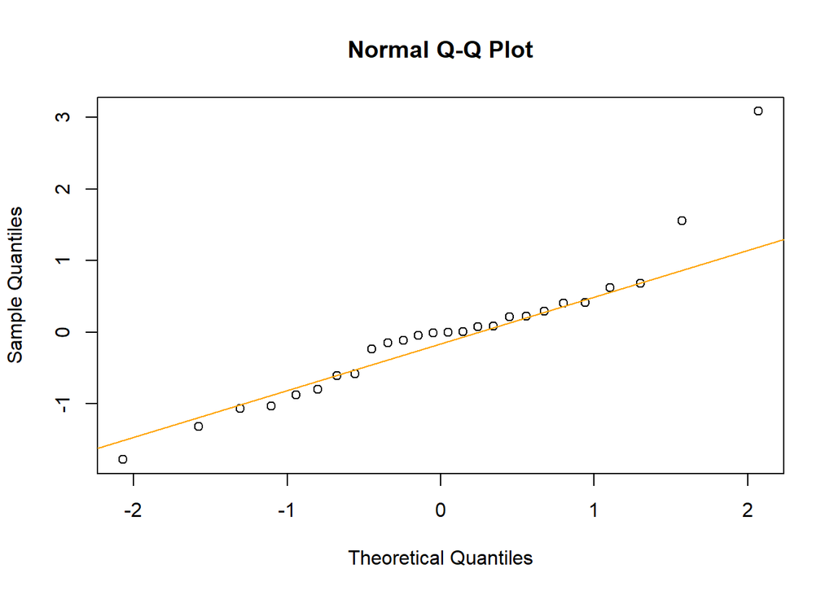

The image illustrates how data is distributed with this model and that there are some outliers.

```
##
##  Shapiro-Wilk normality test
##
## data:  rstandard(ModPol1)
## W = 0.9, p-value = 0.02
```

```
## [1] 534
```

```
## [1] 549
```

We confirm what we supposed, this is not a good model because data is not well dispersed and AIC and BIC presents the highest values at the moment.

**2nd Model, in order**

- Homicide insecurity
- Insecurity in robberies
- Daily wage
- Education
- Employment
- Innovation
- Population Density
- Exports
- Exchange rate
- Year

The model is:

```
##
## Call:
## lm(formula = near2$IED_Flujos ~ near2$Inseguridad_Homicidio +
##     I(near2$Inseguridad_Robo^2) + I(near2$Salario_Diario^3) +
##     I(near2$Educación^4) + I(near2$Empleo^5) + I(near2$Innovación^6) +
##     I(near2$Densidad_Población^7) + I(near2$Exportaciones^8) +
##     I(near2$Tipo_de_Cambio^9) + I(near2$Año^10))
##
## Residuals:
##    Min     1Q Median     3Q    Max
##  -5575  -3096     28   1289  12475
##
## Coefficients:
##                                                                    Estimate
## (Intercept)                   -1354716.519353503128513693809509277343750000
## near2$Inseguridad_Homicidio       1793.377591551199429886764846742153167725
## I(near2$Inseguridad_Robo^2)         -0.084939148277055218083653187477466417
## I(near2$Salario_Diario^3)            0.008583458927656922171633979701255157
## I(near2$Educación^4)                -2.375895495186349570815309562021866441
## I(near2$Empleo^5)                    0.000014084623732396082678060278414733
## I(near2$Innovación^6)                0.001615221310844872863038412802438870
## I(near2$Densidad_Población^7)       -0.000000039813024169947924496386348903
## I(near2$Exportaciones^8)            -0.000000000000000000000000000000000199
## I(near2$Tipo_de_Cambio^9)           -0.000000013042975281327486370211432565
## I(near2$Año^10)                      0.000000000000000000000000001240020023
##                                                                  Std. Error
## (Intercept)                     480447.007503960165195167064666748046875000
## near2$Inseguridad_Homicidio        984.448482893567643259302712976932525635
## I(near2$Inseguridad_Robo^2)          0.127409841998325390477475593797862530
## I(near2$Salario_Diario^3)            0.008442038044581065200921976554582216
## I(near2$Educación^4)                 3.022760569977322564483301903237588704
## I(near2$Empleo^5)                    0.000005660546473801252270567629931719
## I(near2$Innovación^6)                0.000776447039597239862911137731060762
## I(near2$Densidad_Población^7)        0.000000016193745286889398213563823203
## I(near2$Exportaciones^8)             0.000000000000000000000000000000001573
## I(near2$Tipo_de_Cambio^9)            0.000000010423093876449539551013942495
## I(near2$Año^10)                      0.000000000000000000000000000449723267
##                               t value Pr(>|t|)
## (Intercept)                     -2.82    0.013 *
## near2$Inseguridad_Homicidio      1.82    0.088 .
## I(near2$Inseguridad_Robo^2)     -0.67    0.515
## I(near2$Salario_Diario^3)        1.02    0.325
## I(near2$Educación^4)            -0.79    0.444
## I(near2$Empleo^5)                2.49    0.025 *
## I(near2$Innovación^6)            2.08    0.055 .
## I(near2$Densidad_Población^7)   -2.46    0.027 *
## I(near2$Exportaciones^8)        -0.13    0.901
## I(near2$Tipo_de_Cambio^9)       -1.25    0.230
## I(near2$Año^10)                  2.76    0.015 *
## ---
## Signif. codes:  0 '***' 0.001 '**' 0.01 '*' 0.05 '.' 0.1 ' ' 1
##
## Residual standard error: 5200 on 15 degrees of freedom
## Multiple R-squared:  0.789,  Adjusted R-squared:  0.649
## F-statistic: 5.62 on 10 and 15 DF,  p-value: 0.00151
```

In the graph we see a trend but some outliers in this line.

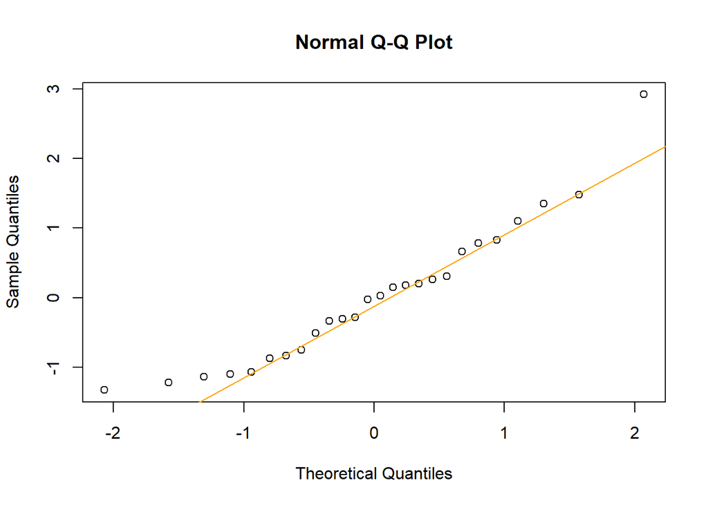

In addition, the data is well distributed, but again the AIC and BIC do not have the best scores.

```
##
##  Shapiro-Wilk normality test
##
## data:  rstandard(ModPol2)
## W = 0.9, p-value = 0.1
```

```
## [1] 528
```

```
## [1] 543
```

**3rd Model, in other order**

Finally, we decided to use these same variables but with the opposite order which is:

- Year
- Exchange rate
- Exports
- Population Density
- Innovation
- Employment
- Education
- Daily wage
- Insecurity in robberies
- Homicide insecurity

This model explains 67% of the behavior of the investment, is significant but not all variables are. In general, we see almost the same values than in the last one.

```
##
## Call:
## lm(formula = near2$IED_Flujos ~ near2$Año + I(near2$Tipo_de_Cambio^2) +
##     I(near2$Exportaciones^3) + I(near2$Densidad_Población^4) +
##     I(near2$Innovación^5) + I(near2$Empleo^6) + I(near2$Educación^7) +
##     I(near2$Salario_Diario^8) + I(near2$Inseguridad_Robo^9) +
##     I(near2$Inseguridad_Homicidio^10))
##
## Residuals:
##    Min     1Q Median     3Q    Max
##  -7530  -1487      4   1315  10600
##
## Coefficients:
##                                                           Estimate
## (Intercept)                       -15765433.0608088206499814987183
## near2$Año                              7922.3147582459623663453385
## I(near2$Tipo_de_Cambio^2)               -48.9699329526668307721593
## I(near2$Exportaciones^3)                  0.0000000000621632091755
## I(near2$Densidad_Población^4)            -0.0130248989755214310271
## I(near2$Innovación^5)                     0.0142975632182691363842
## I(near2$Empleo^6)                         0.0000000277523523677374
## I(near2$Educación^7)                     -0.0003335655091660025143
## I(near2$Salario_Diario^8)                 0.0000000000000104397977
## I(near2$Inseguridad_Robo^9)              -0.0000000000000000000283
## I(near2$Inseguridad_Homicidio^10)         0.0000000000212448165851
##                                                         Std. Error t value
## (Intercept)                         5796673.0139362271875143051147   -2.72
## near2$Año                              2915.7970622388834271987434    2.72
## I(near2$Tipo_de_Cambio^2)                27.2001221213733828108161   -1.80
## I(near2$Exportaciones^3)                  0.0000000002177053015512    0.29
## I(near2$Densidad_Población^4)             0.0054496204431125393544   -2.39
## I(near2$Innovación^5)                     0.0081288437760438543578    1.76
## I(near2$Empleo^6)                         0.0000000467291906627205    0.59
## I(near2$Educación^7)                      0.0017660975592928335100   -0.19
## I(near2$Salario_Diario^8)                 0.0000000000000155294790    0.67
## I(near2$Inseguridad_Robo^9)               0.0000000000000000002486   -0.11
## I(near2$Inseguridad_Homicidio^10)         0.0000000000163749795146    1.30
##                                   Pr(>|t|)
## (Intercept)                          0.016 *
## near2$Año                            0.016 *
## I(near2$Tipo_de_Cambio^2)            0.092 .
## I(near2$Exportaciones^3)             0.779
## I(near2$Densidad_Población^4)        0.030 *
## I(near2$Innovación^5)                0.099 .
## I(near2$Empleo^6)                    0.561
## I(near2$Educación^7)                 0.853
## I(near2$Salario_Diario^8)            0.512
## I(near2$Inseguridad_Robo^9)          0.911
## I(near2$Inseguridad_Homicidio^10)    0.214
## ---
## Signif. codes:  0 '***' 0.001 '**' 0.01 '*' 0.05 '.' 0.1 ' ' 1
##
## Residual standard error: 4990 on 15 degrees of freedom
## Multiple R-squared:  0.806,  Adjusted R-squared:  0.677
## F-statistic: 6.24 on 10 and 15 DF,  p-value: 0.000874
```

Again, we see in our chart a trend but with some outleirs.

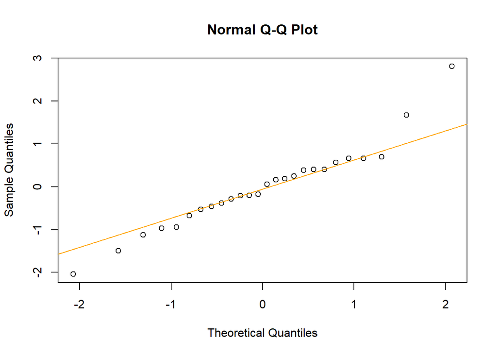

Additionally, we have a good data dispersion, and AIC and BIC are not good enough compared with other models.

```
##
##  Shapiro-Wilk normality test
##
## data:  rstandard(ModPol3)
## W = 1, p-value = 0.2
```

```
## [1] 526
```

```
## [1] 541
```

### Other methods for Regression

**LASSO**

We also tried the LASSO model to look for a better model to our data.

```
##       Año       Exportaciones       Empleo       Educación    Salario_Diario
##  Min.   :1997   Min.   : 9088   Min.   :95.1   Min.   :7.20   Min.   : 24.3
##  1st Qu.:2003   1st Qu.:13260   1st Qu.:96.1   1st Qu.:7.92   1st Qu.: 42.0
##  Median :2010   Median :21188   Median :96.5   Median :8.44   Median : 54.5
##  Mean   :2010   Mean   :23601   Mean   :96.5   Mean   :8.44   Mean   : 65.2
##  3rd Qu.:2016   3rd Qu.:31601   3rd Qu.:97.0   3rd Qu.:8.97   3rd Qu.: 72.3
##  Max.   :2022   Max.   :46478   Max.   :97.8   Max.   :9.60   Max.   :172.9
##    Innovación   Inseguridad_Robo Inseguridad_Homicidio Tipo_de_Cambio
##  Min.   :11.3   Min.   :120      Min.   : 8.04         Min.   : 8.06
##  1st Qu.:12.6   1st Qu.:148      1st Qu.:10.40         1st Qu.:10.75
##  Median :13.1   Median :182      Median :17.11         Median :13.02
##  Mean   :13.1   Mean   :185      Mean   :17.29         Mean   :13.91
##  3rd Qu.:13.6   3rd Qu.:210      3rd Qu.:22.34         3rd Qu.:18.49
##  Max.   :15.1   Max.   :315      Max.   :29.59         Max.   :20.66
##  Densidad_Carretera Densidad_Población CO2_Emisiones  PIB_Per_Cápita
##  Min.   :0.0521     Min.   :47.4       Min.   :3.59   Min.   :126739
##  1st Qu.:0.0595     1st Qu.:52.8       1st Qu.:3.84   1st Qu.:130964
##  Median :0.0699     Median :58.1       Median :3.95   Median :136846
##  Mean   :0.0711     Mean   :57.3       Mean   :3.95   Mean   :138550
##  3rd Qu.:0.0827     3rd Qu.:61.4       3rd Qu.:4.09   3rd Qu.:146148
##  Max.   :0.0902     Max.   :65.6       Max.   :4.22   Max.   :153236
##       INPC
##  Min.   : 33.3
##  1st Qu.: 56.1
##  Median : 73.3
##  Mean   : 75.2
##  3rd Qu.: 91.3
##  Max.   :126.5
```

```
##  [1] 12146  8374 13960 18249 30057 24099 18250 25016 25796 21233 32393 29502
## [13] 17850 27189 25633 21769 48354 30351 35944 31189 34017 34100 34577 28206
## [25] 31554 36215
```

First, we established which variables will be the independent (x) and which others the dependent (y). In this moment we know that IED_Flujos is our dependent variable. We also established lambda values.

Then we separate a sample of the data to create our model.

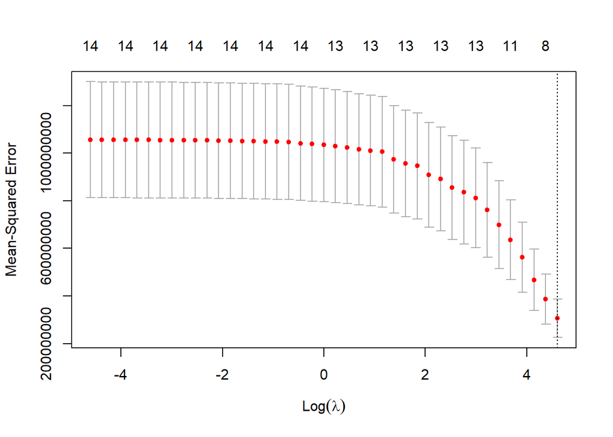

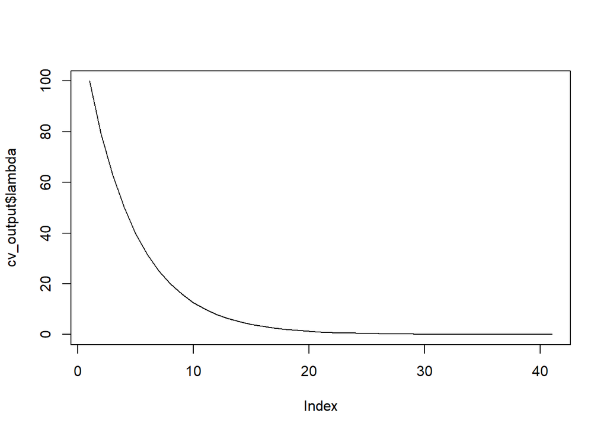

Then we plot our data. The first graph tells us that, according to the LASSO method, we will only use 7 variables to explain the behavior of y.

We also calculate the best value for lambda, which has a value of 100 and create a model with this number.

```
## [1] 100
```

```
##
## Call:
## lm(formula = y_var ~ x_vars)
##
## Residuals:
##    Min     1Q Median     3Q    Max
##  -7097  -1061   -222   1680   4874
##
## Coefficients:
##                                  Estimate    Std. Error t value Pr(>|t|)
## (Intercept)                 -33810874.528   9145063.251   -3.70   0.0035 **
## x_varsAño                       16973.249      4579.182    3.71   0.0035 **
## x_varsExportaciones                -3.286         1.102   -2.98   0.0125 *
## x_varsEmpleo                     5872.763      2495.118    2.35   0.0382 *
## x_varsEducación                -18781.399     13005.656   -1.44   0.1766
## x_varsSalario_Diario             -287.811       252.450   -1.14   0.2785
## x_varsInnovación                 3816.910      1576.380    2.42   0.0339 *
## x_varsInseguridad_Robo             41.595        55.391    0.75   0.4685
## x_varsInseguridad_Homicidio       764.714       555.120    1.38   0.1957
## x_varsTipo_de_Cambio            -3920.133      1047.525   -3.74   0.0033 **
## x_varsDensidad_Carretera      -778218.591   1168172.202   -0.67   0.5190
## x_varsDensidad_Población       -11300.590      5162.372   -2.19   0.0511 .
## x_varsCO2_Emisiones              5040.550     14819.888    0.34   0.7402
## x_varsPIB_Per_Cápita                0.314         0.743    0.42   0.6811
## x_varsINPC                        554.258       974.760    0.57   0.5810
## ---
## Signif. codes:  0 '***' 0.001 '**' 0.01 '*' 0.05 '.' 0.1 ' ' 1
##
## Residual standard error: 4020 on 11 degrees of freedom
## Multiple R-squared:  0.908,  Adjusted R-squared:  0.79
## F-statistic: 7.71 on 14 and 11 DF,  p-value: 0.000833
```

Then we compare it with another model, which has 79% as Adjusted R-squared, is significant and the important variables are Year, Exports, Employment, Innovation and Exchange Rate.

We can see how this data behaves in the following tables. The first one shows us the model using the best value for landa and the other one the model that helped us to compare.

```
##    y_test    s1
## 1   12146 12815
## 4   18249 18365
## 6   24099 21391
## 7   18250 18378
## 9   25796 25791
## 13  17850 28535
```

```
##    y_test    s1
## 1   12146 -8794
## 4   18249 23013
## 6   24099 32539
## 7   18250 36785
## 9   25796 34967
## 13  17850 12426
```

Finally, we calculated the Adjusted R-squared which has a low percentage (55%).

```
## [1] 0.556
```

An the coefficients of the models, the one of the best LASSO and the one to compare, respectively.

```
## 15 x 1 sparse Matrix of class "dgCMatrix"
##                                 s0
## (Intercept)           -5088780.555
## Año                       2558.425
## Exportaciones               -0.423
## Empleo                       .
## Educación                 1087.571
## Salario_Diario               .
## Innovación                2291.775
## Inseguridad_Robo            10.964
## Inseguridad_Homicidio        .
## Tipo_de_Cambio           -2387.891
## Densidad_Carretera           .
## Densidad_Población           .
## CO2_Emisiones            -5751.566
## PIB_Per_Cápita               .
## INPC                         .
```

```
## 15 x 1 sparse Matrix of class "dgCMatrix"
##                                s0
## (Intercept)            -100514.56
## Año                       -915.13
## Exportaciones              -10.29
## Empleo                   14912.67
## Educación               -44506.72
## Salario_Diario            -954.08
## Innovación               -6900.21
## Inseguridad_Robo           271.52
## Inseguridad_Homicidio    -2251.79
## Tipo_de_Cambio           -9429.72
## Densidad_Carretera    10195109.49
## Densidad_Población       -6154.85
## CO2_Emisiones            76120.37
## PIB_Per_Cápita               2.75
## INPC                      4874.28
```

As we can see, our model just takes 7 variables (the LASSO), the other ones are penalized with a 0 value of coefficient. The other one takes all variables and gives them different values for the coefficient.

**Ridge**

We also tried the Ridge method. Our data was already prepared for LASSO, so we will skip this part.

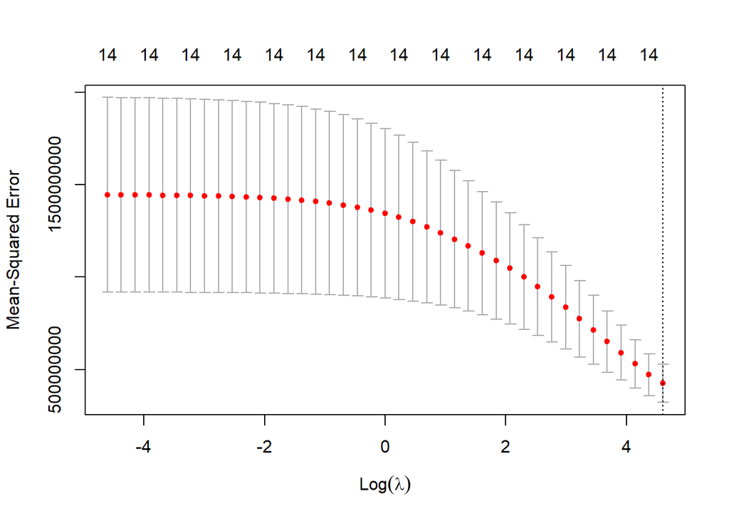

In this graph, we see the behavior of our sample, the bias and variability. We can see that it says that 14 variables will be used (we have a total of 14 columns), because in this method we do not penalize any factor, we only give them lower values.

We also calculate the best lambda (100) and do the corresponding estimates.

```
## [1] 100
```

First, we see an Adjusted R-squared of 0.43 and the following coefficients:

```
## [1] 0.437
```

```
## 15 x 1 sparse Matrix of class "dgCMatrix"
##                                  s0
## (Intercept)           -2728208.5448
## Año                       1357.7668
## Exportaciones               -0.6354
## Empleo                    -191.8398
## Educación                 6437.1706
## Salario_Diario               0.9266
## Innovación                2146.0506
## Inseguridad_Robo            45.6586
## Inseguridad_Homicidio     -348.4983
## Tipo_de_Cambio           -2425.1875
## Densidad_Carretera      139385.2089
## Densidad_Población        -146.5870
## CO2_Emisiones            -4845.0815
## PIB_Per_Cápita              -0.0342
## INPC                       418.9439
```

## Evaluation of the models

At this point, we have 13 models with different structures.Our criterion to select the three best models are:

- Adjusted R-squared
- Shapiro Test
- P-value (level of significance)
- BIC
- AIC

To make a brief summary, we present the following table:

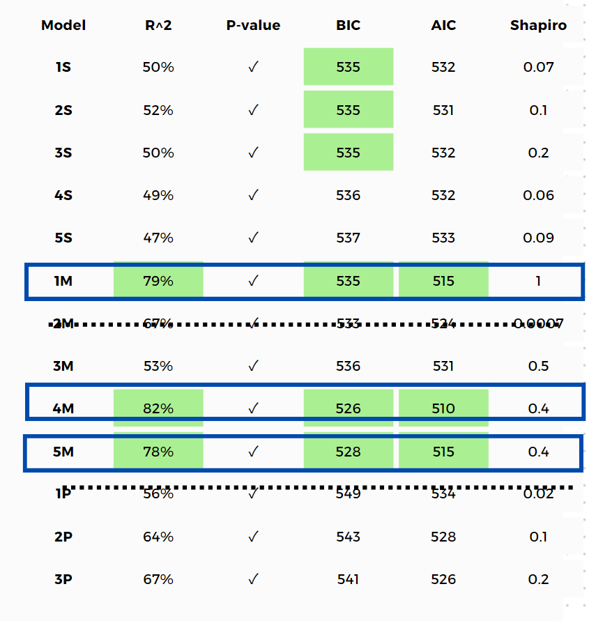

Comparison of the models

- 1st Multiple Linear Regression
- 4th Multiple Linear Regression
- 5th Multiple Linear Regression

We will use some evaluation methods to conclude if these models are good enough for our data:

- Multicollinearity
- Homoscedasticity
  - Breusch - Pagan Test.
  - White Test.
  - Score Test for non-constant error Variance.
- The normality and behavior of the errors

**1st Model Evaluation**

First we do the evaluation for the first multiple model.

*Multicollinearity*

We did the calculation of the coefficients for each variable, but these are a lot of numbers, so a graph might be a better option:

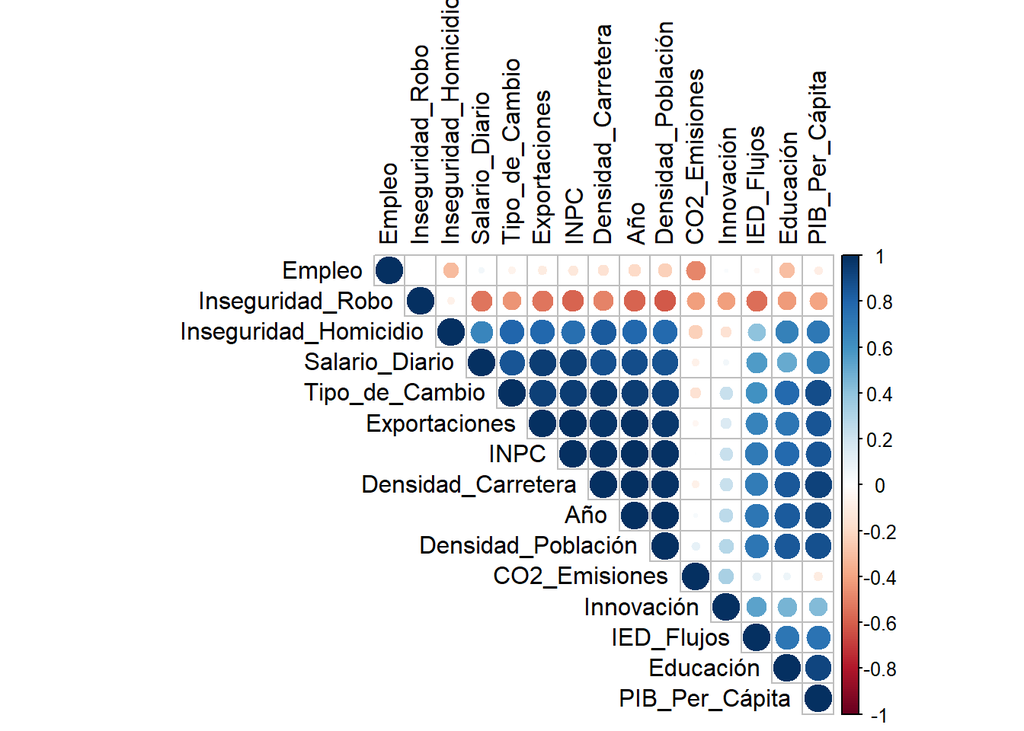

We notice that there is a lot of Multicollinearity between variables, which is not good for our model. This is also affirmed by the VIF estimation, which indicates us Variance Inflation Factor.

```
##                   near2$Año         near2$Exportaciones
##                     1897.60                      241.86
##                near2$Empleo             near2$Educación
##                        5.00                      126.19
##        near2$Salario_Diario            near2$Innovación
##                      126.70                        4.42
##      near2$Inseguridad_Robo near2$Inseguridad_Homicidio
##                       10.78                       24.14
##        near2$Tipo_de_Cambio    near2$Densidad_Carretera
##                       29.24                      377.43
##    near2$Densidad_Población         near2$CO2_Emisiones
##                     1207.17                       11.05
##        near2$PIB_Per_Cápita                  near2$INPC
##                       67.07                      904.64
```

Here we see that only Employment and Innovation are variables that have no relation with y (this because they are equal or lower than 10). This means that only this variables can be used for our model (all the others do not have to be used at the same time) or that we can reduce this Multicollinearity with LASSO or Ridge.

*Homoscedasticity*

With Homoscedasticity we can refer to the phenomenon where the variance of predicted to observed values is constant. The tests made to evaluate this aspect must speculates a not significant value (above 0.05).

The first test is the Breusch-pagan test, which has the following results:

```
##
##  studentized Breusch-Pagan test
##
## data:  ModMulti1
## BP = 14, df = 14, p-value = 0.5
```

Then the white test:

```
##
##  studentized Breusch-Pagan test
##
## data:  ModMulti1
## BP = 26, df = 25, p-value = 0.4
```

And finally the Score test for the non-constant variance:

```
## Non-constant Variance Score Test
## Variance formula: ~ fitted.values
## Chisquare = 2, Df = 1, p = 0.2
```

In the three cases we have non-significant values which is good, we have Homoscedasticity.

*The normality and behavior of the errors*

As our last criterion, we have the behavior of the errors, the closest it is to 0, the better it can be.

```
## [1] -0.000000000000094
```

This is really close to 0, which is good for our model.

**4th Model Evaluation**

Then we have the evaluation for the 4th Multiple Linear Model.

*Multicollinearity*

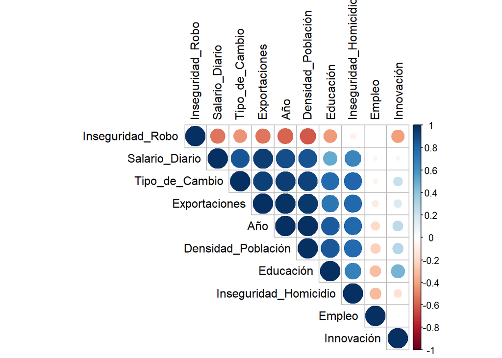

In this graph we see that almost all variables have Multicollinearity except for Employment and Innovation (again). This is confirmed by the VIF calculation:

```
##                   near2$Año         near2$Exportaciones
##                     1135.05                      152.54
##                near2$Empleo             near2$Educación
##                        3.65                       52.89
##        near2$Salario_Diario            near2$Innovación
##                       59.72                        3.51
##      near2$Inseguridad_Robo near2$Inseguridad_Homicidio
##                        8.11                       14.76
##        near2$Tipo_de_Cambio    near2$Densidad_Población
##                       21.45                      358.32
```

We notice that also Insecurity of robberies can be used in the same model with the two factors mentioned above. However, the other variables are not recommended to be used in the same model because of Multicollinearity and have to be fixed with a LASSO or Ridge method.

*Homoscedasticity*

On the other hand, we apply the three tests for Homoscedasticity. First we start with the Breusch-pagan test:

```
##
##  studentized Breusch-Pagan test
##
## data:  ModMulti4
## BP = 13, df = 10, p-value = 0.2
```

Then the White test:

```
##
##  studentized Breusch-Pagan test
##
## data:  ModMulti4
## BP = 26, df = 25, p-value = 0.4
```

And finally the Score test for the non constant variance:

```
## Non-constant Variance Score Test
## Variance formula: ~ fitted.values
## Chisquare = 1.66, Df = 1, p = 0.2
```

In the three cases is presented a non-significant p-value, so it is a good result for our model.

*The normality and behavior of the errors*

We finish with the behavior of the errors in our model by calculating the mean of the errors which have to be almost equal to 0.

```
## [1] 0.000000000000212
```

This is a good result for the 4th Multiple Linear Model.

**5th Model Evaluation**

We end with the evaluation of the 5th Multiple Linear Model with the same criterion.

*Multicollinearity*

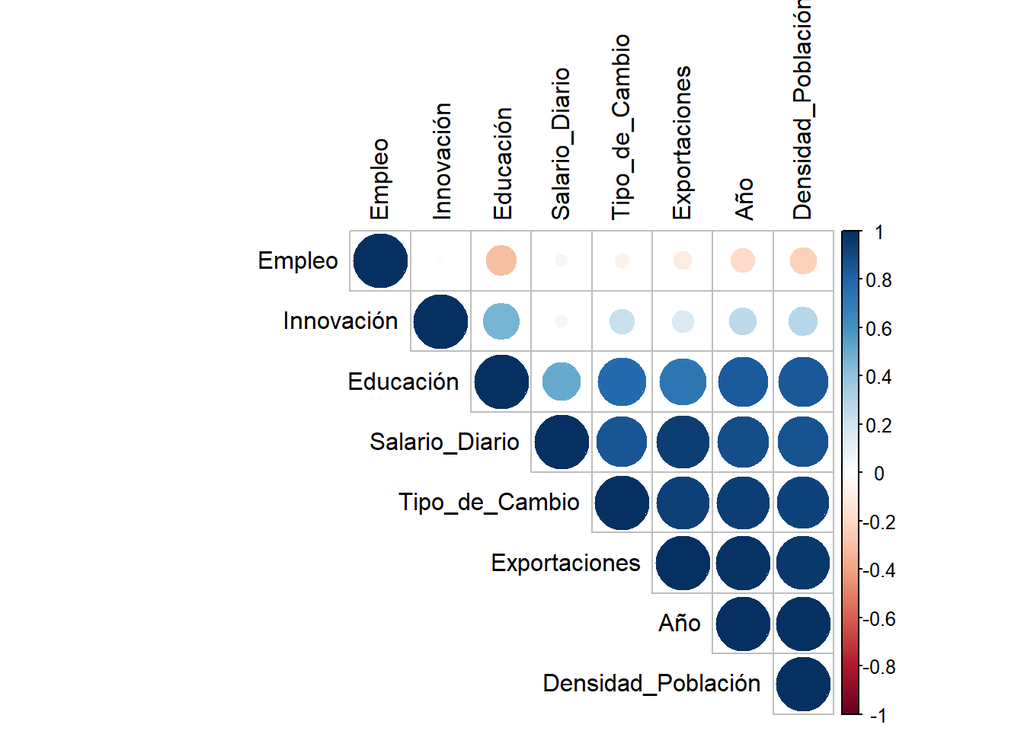

First we do this by graphing the correlation between variables. The image above illustrates this. Again, Employment and Innovation are factors with no Multicollinearity.

```
##                near2$Año      near2$Exportaciones             near2$Empleo
##                   844.59                    98.18                     2.29
##          near2$Educación     near2$Salario_Diario         near2$Innovación
##                    28.90                    42.18                     1.58
##     near2$Tipo_de_Cambio near2$Densidad_Población
##                    13.52                   291.33
```

And the VIF estimation corroborates this with a score of 2.29 for Employment and 1.58 for Innovation. The other variables can be treated with the LASSO or Ridge method.

*Homoscedasticity*

We also try the three tests for this model. The Breusch-Pagan indicates the following information:

```
##
##  studentized Breusch-Pagan test
##
## data:  ModMulti5
## BP = 15, df = 8, p-value = 0.05
```

The White test speculates the following:

```
##
##  studentized Breusch-Pagan test
##
## data:  ModMulti5
## BP = 26, df = 25, p-value = 0.4
```

And the Score test for the non constant variance tells us these estimations:

```
## Non-constant Variance Score Test
## Variance formula: ~ fitted.values
## Chisquare = 1.31, Df = 1, p = 0.3
```

The White test and the Score test for the non constant variance are above 0.05, which is good. However, the Breusch-pagan test is equal to this value. This is good because it is not lower than, but it could mean that the estimated variance of the residuals of the regression depend on the values of the x variables.

*The normality and behavior of the errors*

Finally, we applied the mean function to calculate the average of the errors in the model.

```
## [1] 0.00000000000000651
```

This value is close to 0, so it is good for our model.

## Conclusion

**Which is the best model to predict the effect of nearshoring in Mexico?**

*-25055259.671+(12656.140Year)+(-1.965Exports)+(3080.346Employment)+(-7423.193Education)+(-126.519Daily wage)+(2324.721Innovation)+(-3028.813Exchange rate)+(-9047.235Population Density)*

**What areas of opportunity has Mexico in order to increase foreign investment?**

The factors that should be considered to increase external investing are the ones used in our model:

- Year
- Exports
- Employment
- Education
- Daily wage
- Innovation
- Exchange Rate
- Population Density

However, there are some factors that have a bigger impact in the decision making of external entrepreneurship (these ones were selected according to its level of significance in our model), which are:

- Year: We cannot do anything with this variable but take advantage of time to improve other factors.
- Exports: Promote the exports of different industries (the data presented do not cover petroleum, but textile companies).
- Innovation: Promote innovation in processes, products, marketing, digital transformation, technology, etc. This by creating programs and activities (in school or outside of it) that boost creativity, imagination, the creation of new things and problem solving. It is also important to inform about the register of patents.
- Exchange Rate: Taking care of the exchange rate of our country by maintaining the interest rate, keeping relations with Canada and United States and by keeping public spending moderate and maintaining good debt levels. (Rodríguez, 2023).
- Population Density: Keep low rates of growth in population, we noticed that if population increases, investment decreases.

So, these are the things we have to take care about in order to increase financing in our country and give better opportunities for our people.

## Bibliography

- Shih, Willy. (September-October 2020). “Global Supply Chains ina Post-Pandemic World”: Harvard Business Review.
- Lázaro, E. (2022). *¿Qué es el nearshoring?.* El Economista. https://www.eleconomista.com.mx/empresas/Que-es-el-nearshoring-20221108-0093.html
- Secretaría de Economía (2023). *Inversión Extranjera Directa.* Secretaría de Economía.
- Rodríguez, J. (2023). *¿QUÉ SOSTIENE EL VALOR DEL PESO MEXICANO?*. IPADE Business School. https://www.ipade.mx/2023/02/17/que-sostiene-el-valor-del-peso-mexicano/